# ProyectoTD2026

Tratamiento de los Datos. Grado en Ciencia de Datos- UV

GrupoH

2026-05-15

**Simple Summary:** Este proyecto analiza cómo los estudiantes de Ciencia de Datos interactúan con el Aula Virtual en la asignatura “Tratamiento de Datos”. Al estudiar su rastro digital (clics), hemos identificado los horarios preferidos de estudio, si los alumnos dejan las tareas para el último momento y si prefieren trabajar desde el campus o desde casa. El objetivo final es proporcionar a los profesores una herramienta visual que les ayude a entender mejor las necesidades del grupo y mejorar la organización de la asignatura.

**Palabras clave:** Análisis, Moodle, R, limpieza de datos, Tratamiento de Datos.

# 1 Introduccion

## 1.1 Contexto del proyecto

La digitalización de la enseñanza superior ha transformado las plataformas de aprendizaje virtual, como Moodle, en fuentes masivas de datos. Cada interacción de un estudiante genera un registro que, analizado correctamente, puede revelar patrones de comportamiento invisibles a simple vista.

Este proyecto surge de la necesidad de aplicar técnicas de Ciencia de Datos sobre el conjunto de registros de la asignatura “Tratamiento de Datos” de la Universitat de València. El propósito no es solo limpiar y organizar la información, sino realizar un Análisis Exploratorio de Datos (AED) profundo que nos permita comprender la dinámica del curso durante el segundo cuatrimestre.

## 1.2 Preguntas de investigación

Para alcanzar el objetivo establecido, el trabajo se estructura en torno a la resolución de las siguientes preguntas de investigación:

- ¿En qué días de la semana y franjas horarias se concentran los mayores picos de actividad de los alumnos?
- ¿Es posible identificar y agrupar a los alumnos en distintos “perfiles de estudiante” (ej. constantes, de última hora, inactivos) según sus patrones de uso del Aula Virtual?
- ¿Con cuánta antelación entregan el Miniproyecto los alumnos?
- ¿Existe una diferencia significativa en la actividad de los alumnos entre los días laborables y los fines de semana o festivos?
- ¿Qué porcentaje de la actividad se realiza en la ETSE y qué porcentaje se realiza fuera de esta?
- ¿Hay más actividad provocada por las tareas o se produce más para revisar los apuntes de cada tema?

# 2 Metodología y Preparación de Datos

La fase de preparación de datos es la etapa crítica de este proyecto, para garantizar la calidad, consistencia y fiabilidad de los resultados. En esta sección se detalla el proceso de ingesta, limpieza y transformación del conjunto de datos original (`logs_moodle_anon.csv`), adaptándolo para el Análisis Exploratorio de Datos.

Para llevar a cabo este procesamiento, se ha utilizado el entorno de programación R, empleando la colección de paquetes `tidyverse` para la manipulación eficiente de *dataframes* y la librería `lubridate` para el tratamiento avanzado de series temporales.

El flujo de trabajo aplicado consta de las siguientes fases metodológicas:

## 2.1 Importación y estandarización

En primer lugar, se procede a la carga del archivo original. Las bases de datos provenientes de sistemas como Moodle suelen contener nombres de columnas con espacios y caracteres especiales. Para facilitar el manejo programático y mantener un código limpio, se han renombrado estas variables bajo un estándar consistente (por ejemplo, transformando “Nombre completo del usuario” a `usuario` y “Contexto del evento” a `contexto`).

## 2.2 Gestión temporal e Ingeniería de variables

Dado que gran parte de nuestras preguntas de investigación tienen un carácter cronológico, la variable original de tiempo se ha convertido al formato estándar de fecha y hora (`POSIXct`) mediante la función `dmy_hms()`. A partir de esta marca temporal, se han extraído e ingeniado nuevas características (*feature engineering*) que serán fundamentales para el análisis: la fecha exacta (`fecha`), la hora del día (`hora`), el día de la semana (`dia_semana`) y el mes (`mes`).

## 2.3 Limpieza, tipado y filtrado

Para delimitar el alcance del estudio al periodo lectivo correspondiente, se ha aplicado un filtro para conservar exclusivamente los registros del cuatrimestre activo (del 1 de enero al 31 de julio de 2025).

Además, se ha realizado una conversión de tipos de datos (*Type casting*), transformando las variables de naturaleza categórica a formato *factor*. Esta operación no solo optimiza el uso de la memoria, sino que es un requisito indispensable para la correcta generación de gráficos y la aplicación de métodos estadísticos. Finalmente, para asegurar la integridad de la información, se han eliminado los posibles registros duplicados del sistema, obteniendo así nuestro conjunto de datos final y limpio.

# 3 Análisis y visualización de datos.

El Análisis Exploratorio de Datos constituye la fase central de nuestro estudio. En esta etapa, aplicamos técnicas estadísticas y de visualización para descubrir patrones, comprender la distribución de la actividad en el Aula Virtual y asentar las bases antes de responder a las preguntas de investigación.

## 3.1 Análisis Estructural y Diccionario de Datos

A continuación, en la Tabla 3.1 se exponen las métricas generales que dimensionan el ecosistema de la asignatura, mostrando la cantidad de alumnos implicados y la diversidad de acciones que pueden realizar.

Table 3.1: Resumen estructural del conjunto de datos.

| Métrica | Valor |
| --- | --- |
| Total de registros (limpios) | 102809 |
| Usuarios únicos | 83 |
| Tipos de eventos distintos | 106 |
| Componentes distintos | 25 |

Para garantizar la reproducibilidad y la correcta interpretación de los análisis posteriores, es indispensable documentar el estado final de las características del dataframe. El Diccionario de Datos resultante, donde se especifican los tipos (como Factor o POSIXct), se presenta en la Tabla 3.2.

Table 3.2: Diccionario de datos final tras el proceso de ingeniería de variables.

| Variable | Tipo | Descripción |
| --- | --- | --- |
| fecha_hora | POSIXct (datetime) | Marca de tiempo completa (fecha y hora). |
| usuario | Factor | Identificador único del usuario (anonimizado). |
| usuario_afectado | Factor | Usuario sobre el que recae la acción (si aplica). |
| contexto | Factor | Entorno o curso donde ocurre el evento. |
| componente | Factor | Módulo de Moodle (Tarea, Foro, Sistema, etc.). |
| evento | Factor | Acción específica realizada por el usuario. |
| descripcion | Character | Descripción detallada de la interacción. |
| origen | Factor | Plataforma de acceso (web o móvil). |
| ip | Character | Dirección de red del dispositivo (IPv4/IPv6). |
| fecha | Date | Fecha del evento (YYYY-MM-DD). |
| hora | Integer | Hora del día en formato 24h (0-23). |
| dia_semana | Ordered Factor | Día de la semana (Lunes-Domingo). |
| mes | Ordered Factor | Mes del año (Enero-Diciembre). |

## 3.2 Exploración Univariante: Distribución de la actividad general

Una vez validada la integridad y estructura de la información, procedemos a examinar cómo se distribuyen de forma general estos registros. Comprender en qué momentos del día interactúan los alumnos con la plataforma es vital para establecer el ritmo base de la asignatura.

Como ejemplo principal de esta exploración univariante, la Figura 3.1 ilustra la frecuencia de los accesos e interacciones a lo largo de las distintas horas del día. Esta visualización nos permite identificar de un vistazo las franjas de mayor rendimiento y los periodos de inactividad nocturna.

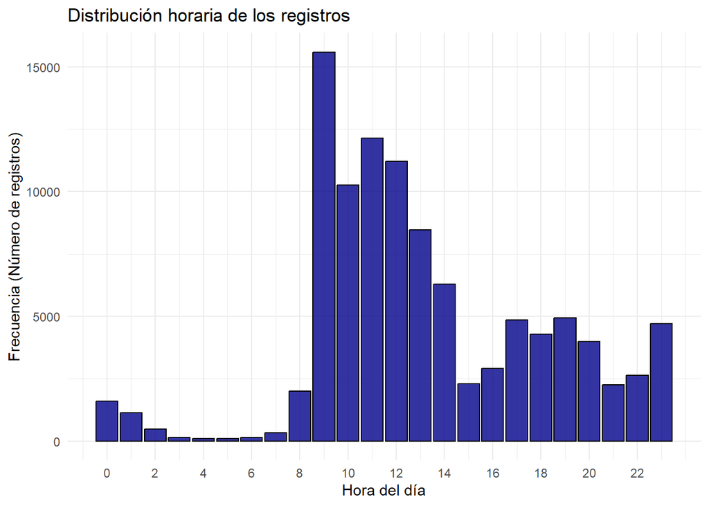

Figure 3.1: Distribución horaria de los registros

## 3.3 Detección y análisis de valores atípicos (Outliers)

Cuando analizamos los datos del Aula Virtual, nos damos cuenta de que no todos los alumnos usan la plataforma de la misma manera. Mientras que la mayoría mantiene un ritmo de trabajo parecido, siempre hay estudiantes que interactúan muchísimo más de lo normal, o por el contrario, muy por debajo de la media.

Para identificar matemáticamente a estos estudiantes con comportamientos extremos, hemos sumado el número total de interacciones (clics) que ha hecho cada alumno durante el cuatrimestre y hemos aplicado el método estadístico del Rango Intercuartílico (IQR).

Este método nos permite calcular unos límites matemáticos para definir qué es un comportamiento normal y qué se sale de lo común. En base a esto, hemos clasificado a los estudiantes en tres perfiles:

**Hiperactivos**: Aquellos que superan el límite superior, es decir, interactúan con la plataforma mucho más que el resto de la clase.

**Inactivos extremos**: Aquellos que se quedan por debajo del límite inferior.

**Normales**: El estandar de la clase, que se mueve dentro de los límites esperados.

La Figura 3.2 muestra la distribución de la actividad por estudiante mediante un diagrama de caja (boxplot), acompañado de los puntos individuales correspondientes a cada usuario.

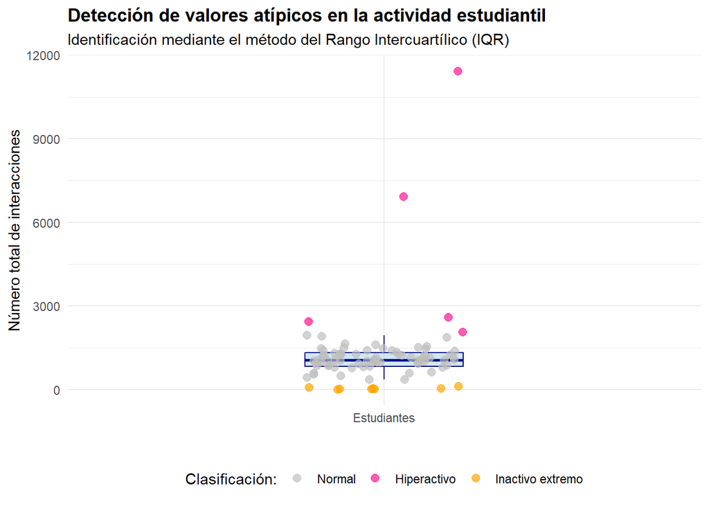

Figure 3.2: Distribución del volumen de actividad por usuario.

Como se puede observar a simple vista en el gráfico, la gran mayoría de los alumnos (los puntos grises) se agrupan en la parte baja, dentro y cerca de la caja azul, representando el comportamiento normal del grupo.

Sin embargo, lo que más llama la atención de esta visualización es la presencia de puntos rojos muy alejados del resto, en especial un estudiante (o pequeño grupo) situado en la parte más alta del gráfico, con un volumen de interacciones completamente desproporcionado respecto a sus compañeros.

Como nos ha parecido un un caso ta extraño ya que la diferencia con la mayoria de estudiantes es abismal le hemos intentado dar dos explicaciones lógicas a este exceso masivo de clics:

La primera se relaciona con un comportamiento humano inususal, podría tratarse de un alumno que utiliza el Aula Virtual como su única herramienta de consulta en tiempo real, abriendo y cerrando recursos compulsivamente en lugar de descargar los apuntes en su ordenador.

La segunda explicación que se nos ha ocurrido es que es muy probable que no sean clics reales hechos a mano. Puede deberse a que el alumno haya dejado la pestaña de Moodle abierta con una extensión de navegador que recarga la página automáticamente (auto-refresh), o que haya utilizado algún script o bot para descargar todos los materiales de la asignatura de golpe.

Para tener un mayor control sobre estos casos aislados, en la Tabla 3.3 detallamos exactamente cuántos clics han realizado los estudiantes identificados como atípicos.

Table 3.3: Detalle de los estudiantes clasificados con un comportamiento atípico.

| Identificador (Usuario) | Total de Clics | Perfil Asignado |
| --- | --- | --- |
| U0072 | 11431 | Hiperactivo |
| U0001 | 6916 | Hiperactivo |
| U0006 | 2582 | Hiperactivo |
| U0012 | 2434 | Hiperactivo |
| U0069 | 2059 | Hiperactivo |
| U0014 | 113 | Inactivo extremo |
| U0040 | 66 | Inactivo extremo |
| U0045 | 44 | Inactivo extremo |
| U0053 | 40 | Inactivo extremo |
| U0101 | 16 | Inactivo extremo |
| U0002 | 8 | Inactivo extremo |
| U0057 | 7 | Inactivo extremo |
| U0010 | 3 | Inactivo extremo |

Aunque el método estadístico IQR ha detectado múltiples valores atípicos, es fundamental interpretar estos datos desde un punto de vista pedagógico antes de eliminarlos ciegamente.

Por un lado, los valores atípicos inferiores (alumnos con muy pocos clics) representan una realidad común en el ámbito universitario: el abandono de la asignatura. Estos registros son reales y no distorsionan el comportamiento de estudio. Del mismo modo, los alumnos levemente hiperactivos representan perfiles de alta implicación que también enriquecen el análisis.

Para determinar si los alumnos hiperactivos són bots o simplemente alumnos muy estudiosos y que durante todo el curso, dia tras dia se meten en el aula virtual, representamos la distribución de sus clics en la Figura3.3

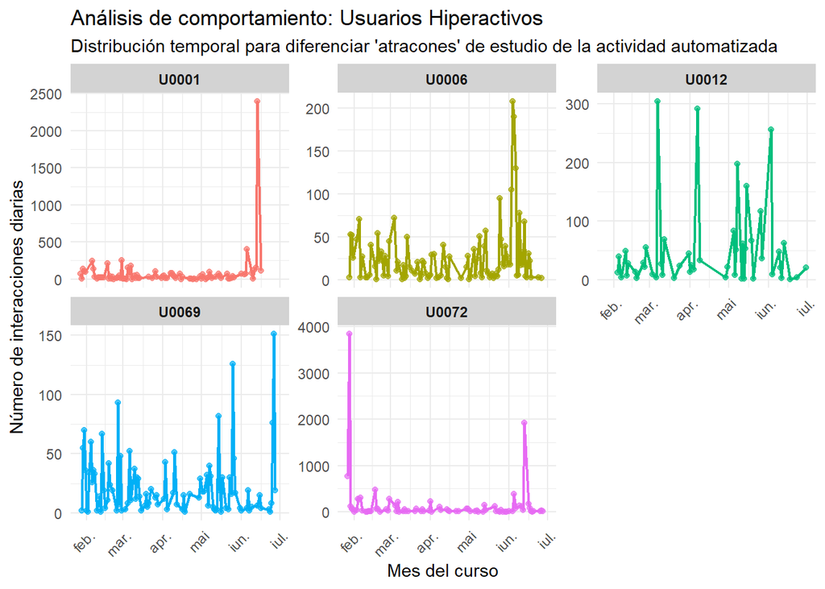

Figure 3.3: Análisis de comportamiento: Usuarios Hiperactivos.

Consideramos que es imposible realizar 2000 o 200 clics al dia, a no ser que se trate de un profesor poniendo notas, por ejemplo. Por ello, eliminamos a estos usuarios del nuestro banco de datos para que no generar resultados sesgados.

# 4 Resultados: Respuesta a las Preguntas de Investigación

## 4.1 ¿ En qué días de la semana hay más picos de actividad?

Table 4.1: Distribución del volumen de actividad por día de la semana.

| dia_semana | total_clics | porcentaje |
| --- | --- | --- |
| luni | 10575 | 13.7 |
| marți | 11178 | 14.4 |
| miercuri | 20377 | 26.3 |
| joi | 11474 | 14.8 |
| vineri | 14687 | 19.0 |
| sâmbătă | 3738 | 4.8 |
| duminică | 5358 | 6.9 |

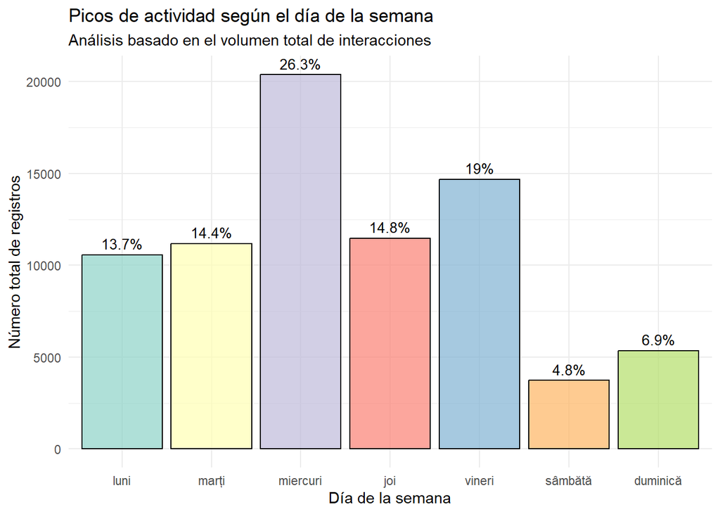

Figure 4.1: Picos de actividad según el día de la semana

**Picos de máxima actividad:** Los días con mayor volumen de interacción son el **miércoles con un 26.3%** y el **viernes con un 19%**. Estos picos nos pueden insinuar que los miércoles y viernes es cuando habian clases presenciales de esta asignatura y de ahi sus picos de recurrencia.

**Desconexión en el fin de semana:** En la gráfica podemos observar una leve bajada que comienza el sabado dia en el cual podemos ver en nuestra gráfica es cuando nuestro número de registros toca fondo con un **4.8%**, siendo el día de menor actividad. Esto sugiere un patrón de comportamiento donde el alumnado prioriza el descanso tras la semana lectiva y es mas activo los dias de clase. Esto tambien lo podemos ver por el hecho de que de los dias de Lunes a viernes se concentra de toda la acla mayor parte de toda la actividad semanal.

## 4.2 ¿Cuáles son las horas a las que prefieren estudiar los alumnos de Tratamiento de datos?

Como se puede observar en la Figura 4.2 y en la Figura 4.3, en cuanto a las horas:

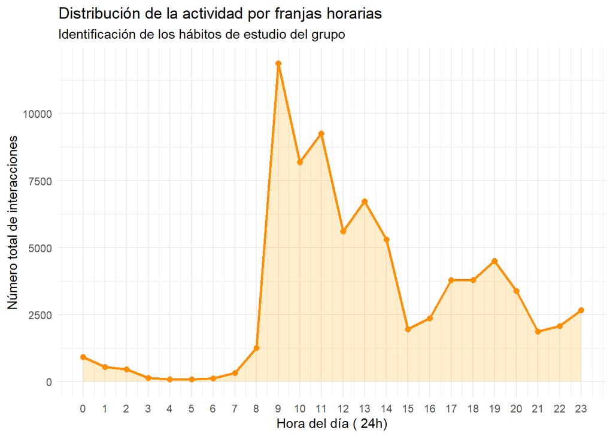

Figure 4.2: Distribución de la actividad por franjas horarias.

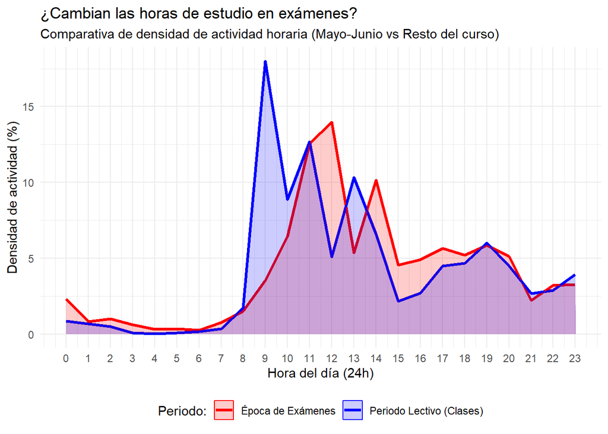

Figure 4.3: Comparativa de densidad de franjas horarias examenes vs resto del curso.

**Bajada de medio dia:** A parte observamos, que sobre las 15 hay una bajada bastante grande de actividad la cual podemos entender por ser horas en dond elos alumnos estaran saliendo de clase, comiendo y descansanso.

**Periodo de tarde:** más tarde a partir de las 17:00 podemos ver como aumentan las entradas a “Tratamiento de datos” de forma moderada horas que seguramente usan los estudiantes ya para estudiar.

**Periodo de inactividad:**Y ya vemos una inactividad a las horas de madrugada que relacionamos con las horas de sueño de los estudiantes.

## 4.3 ¿Es posible identificar y agrupar a los alumnos en distintos “perfiles de estudiante” (ej. constantes, de última hora, inactivos) según sus patrones de uso del Aula Virtual?

Para segmentar a los estudiantes de la forma más realista posible, hemos utilizado un modelo basado en dos variables: la constancia (días distintos de conexión) y la intensidad de estudio (media de clics realizados por cada día activo). Utilizando las medianas de la clase como puntos de corte, la distribución revela tres perfiles muy definidos:

**Perfil Constante (53.8%):** Algo más de la mitad de la clase (42 estudiantes) mantiene un hábito de estudio regular, conectándose al Aula Virtual más días que la mediana del grupo.

**Perfil de Baja Participación (20.5%):** Finalmente, identificamos a 16 estudiantes que se encuentran por debajo de la mediana tanto en días de conexión como en intensidad de uso. Este grupo representa el alumnado en riesgo de abandono o suspenso, y su detección temprana sería de gran utilidad para que el equipo docente pudiera aplicar medidas de refuerzo.

Como resultado nos ha salido la Figura 4.4

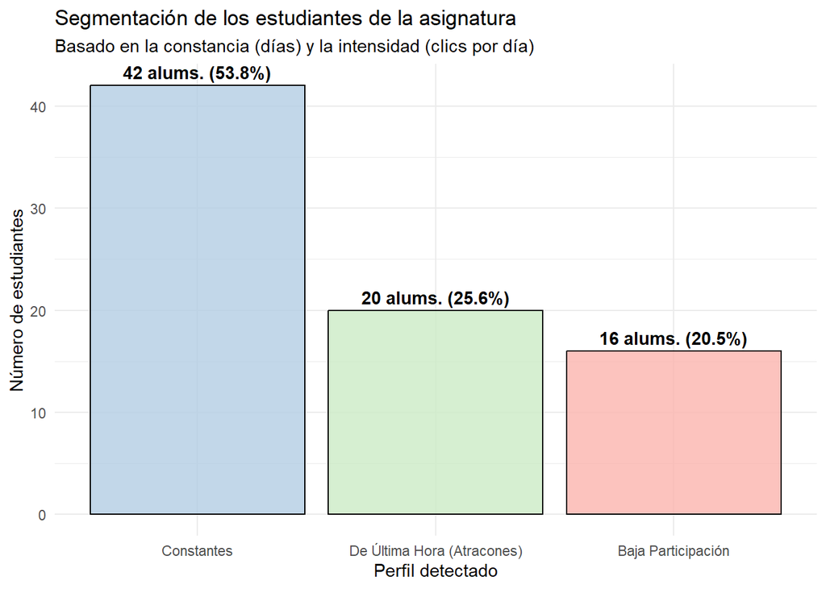

Figure 4.4: Distribución de los perfiles de estudiante.

## 4.4 ¿Con cuánta antelación entregan el Miniproyecto los grupos de alumnos?

Una de las métricas más interesantes para entender los hábitos de estudio del alumnado es su grado de planificación frente a las fechas límite. Al calcular la diferencia en horas entre el último archivo enviado por cada grupo y la hora de cierre del Miniproyecto, los resultados revelan una alarmante tendencia hacia la procrastinación extrema.

La fecha de cierre del Miniproyecto la hemos sacado de el curso archivado 2024-2025 de una estudiante.

Como se puede observar en la gráfica, la opción mayoritaria sigue siendo realizar el envío final en el último minuto (46.4%), es decir, con menos de 6 horas de margen respecto al cierre de la plataforma. Si a esto le sumamos el 15.5% que entrega durante ese mismo día y el 17.9% que lo hace la jornada anterior, comprobamos que prácticamente el 80% (79.8%) de los grupos concentra la subida de su proyecto en las últimas 48 horas. Por el contrario, uno de cada cinco grupos (20.2%) demuestra una alta planificación, realizando la entrega con más de dos días de antelación.

Estos datos confirman de forma rotunda el patrón de “trabajo por atracón” fuertemente condicionado por las fechas límite. Desde un punto de vista técnico, que casi la mitad de los grupos de la clase intente subir sus archivos al Aula Virtual en la misma franja de 6 horas es un dato crítico. Esta métrica explica los picos de actividad en los servidores de la universidad y justifica las habituales ralentizaciones durante los días clave de evaluación.

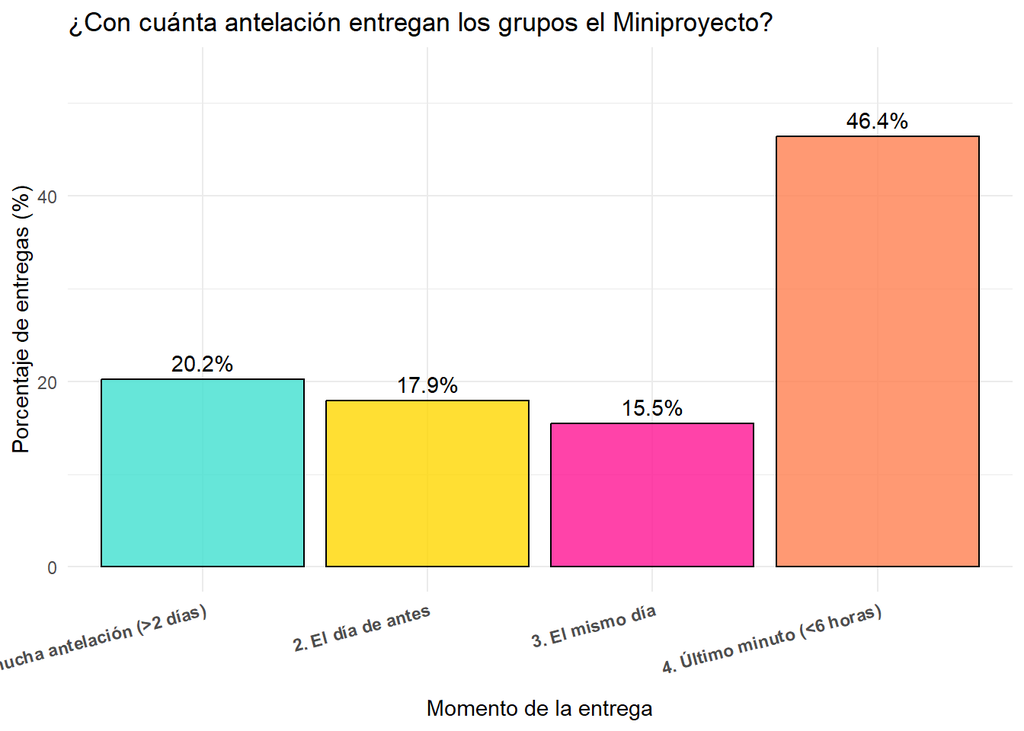

Figure 4.5: Antelación en la entrega del Miniproyecto por parte de los grupos.

## 4.5 ¿Existe una diferencia significativa en la actividad de los alumnos entre los días laborables y los fines de semana o festivos?

Para entender cómo afecta el calendario oficial (CALENDARIO ACADÉMICO, CURSO 2024-25 UNIVERSITAT DE VALÈNCIA) a los hábitos de estudio del alumnado, hemos analizado la distribución del volumen diario de interacciones clasificando los días del cuatrimestre en tres categorías: Laborables, Fines de semana y Festivos oficiales (sin clase).

Como se puede observar visualmente en la Figura 4.6, existe una diferencia muy significativa en el comportamiento de los estudiantes dependiendo del tipo de día:

**Días Laborables:** Concentran el mayor volumen de actividad regular y la mayor variabilidad. La línea central de la caja verde muestra una mediana de interacciones muy superior al resto de días. Además, resultan de gran interés los valores atípicos superiores. Estos puntos no son errores, los outliers temporales corresponden a jornadas lectivas clave, como las fechas de entrega del Miniproyecto o las vísperas de exámenes, donde la actividad conjunta de toda la clase se dispara, confirmando el patrón de “estudio por atracón” detectado en apartados anteriores.

**Fines de Semana:** Muestran una caída drástica en la mediana de interacciones, lo que indica un patrón generalizado de desconexión académica por parte de la mayoría de la clase. No obstante, se aprecian algunos picos puntuales que sugieren que ciertos estudiantes utilizan el fin de semana exclusivamente cuando hay fechas límite inminentes.

Los datos demuestran que la dinámica de uso de la plataforma virtual está fuertemente condicionada por el calendario presencial. Los estudiantes no distribuyen su carga de trabajo de forma uniforme a lo largo de la semana, sino que concentran su esfuerzo casi exclusivamente en los días laborables ordinarios y, de forma masiva, en los días inmediatamente previos a una evaluación.

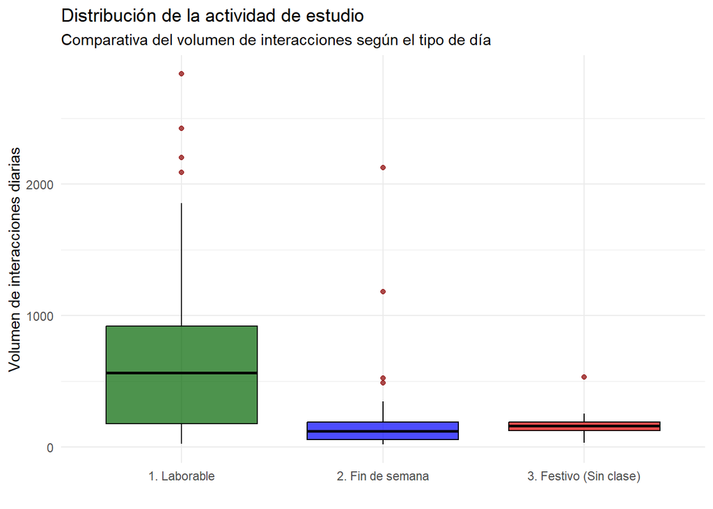

Figure 4.6: Actividad de los alumnos: días sin universidad vs días laborables

## 4.6 ¿Qué porcentaje de la actividad se realiza en la ETSE y qué porcentaje se realiza fuera de esta?

Para determinar si el uso del Aula Virtual se realiza principalmente en las instalaciones de la universidad o de forma remota, hemos analizado las direcciones IP de origen de cada interacción. Para garantizar la máxima precisión técnica, el algoritmo se ha diseñado para identificar tanto el rango clásico IPv4 de la Universitat de València (147.156.x.x) como el rango de nueva generación IPv6 asignado a través de RedIRIS (2001:720:1014::), capturando así todo el tráfico de la red eduroam y de los laboratorios. Sabemos que estas son las direcciónes IP de la ETSE ya que conectados a eduroam hemos mirado que IP teniamos.

A pesar de tener un porcentaje menor, es destacable el altísimo volumen de actividad registrado en la ETSE (más de 32.600 interacciones). Este 42.4% demuestra que Moodle no es solo una herramienta de trabajo a distancia, sino que está integrada en la presencialidad. Los alumnos acceden masivamente a la plataforma desde la facultad, una métrica que se explica por la descarga de guiones durante las clases de laboratorio, el seguimiento de recursos en las clases teóricas o las horas de estudio en la biblioteca del campus.

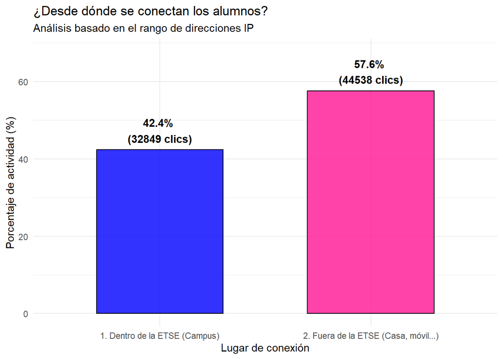

Figure 4.7: Porcentaje de actividad dentro de la ETSE vs fuera.

## 4.7 ¿Hay más actividad provocada por las tareas o se produce más para revisar los apuntes de cada tema?

Por último, se ha comparado el volumen de interacciones entre los dos recursos principales de la plataforma: los materiales de estudio (Apuntes) y las actividades evaluables (Tareas/Entregas). Esto se ve en la Figura 4.8

Como evidencia de forma contundente el gráfico superior, existe una desproporción masiva en el uso de ambos recursos. Las interacciones con las Tareas superan con creces las 22.000 acciones, multiplicando por más de cinco el volumen de clics destinados a la visualización o descarga de Apuntes.

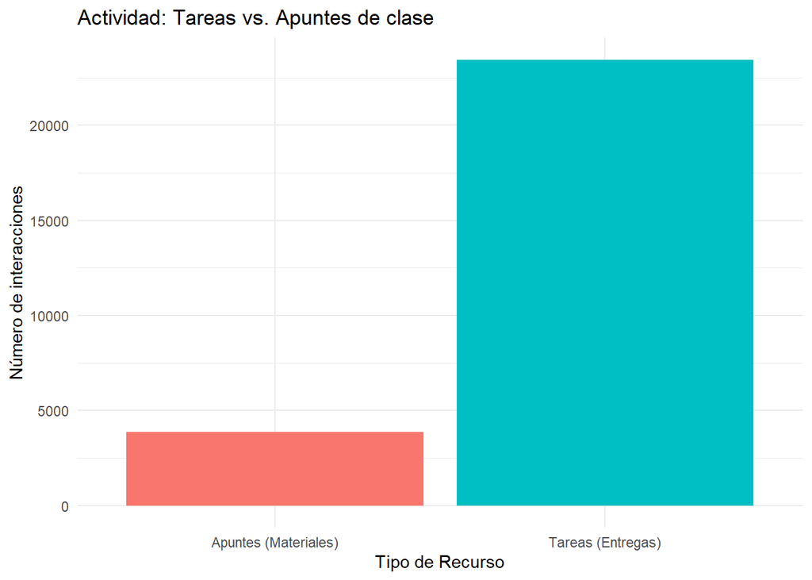

Figure 4.8: Actividad de tareas vs apuntes.

# 5 Conclusiones

El primero, trata de clasificar moodle como un portal de entregas, los datos demuestran que los alumnos tienen un enfoque totalmente práctico. Usan la plataforma principalmente para aquello que tiene impacto en su nota (las Tareas), mientras que la consulta de los materiales teóricos (Apuntes) es mínima. El estudiante prefiere descargar el temario una vez y no volver a interactuar con él, entrando al sistema casi exclusivamente para enviar sus trabajos.

Por último, detectamos que los estudiantes consideran que los días festivos son para descansar, el análisis del calendario y las ubicaciones rompe el mito de que el Aula Virtual es solo para estudiar los fines de semana. Por un lado, hemos visto que la actividad en festivos y fines de semana cae en picado, demostrando que los alumnos siguen el ritmo del calendario oficial. Por otro lado, un sorprendente 40% del tráfico se genera desde el propio campus (ETSE), lo que demuestra que la plataforma digital es un apoyo constante también durante las clases presenciales.

Conocer esta realidad a través de la Ciencia de Datos es una herramienta de inmenso valor, ya que permite a los profesores diseñar asignaturas más adaptadas a la realidad y a los informáticos preparar los sistemas para que no colapsen en el momento de la verdad: el último minuto antes del cierre.

**Acknowledgments:** Agradecemos al profesorado de la asignatura Tratamiento de Datos por facilitar los datos para este análisis y su apoyo en la resolución de dudas técnicas.

**Abbreviations:** The following abbreviations are used in this manuscript:

| **AED** | Análisis Exploratorio de Datos |
| --- | --- |
| **IQR** | Rango Intercuartílico |
| **ETSE** | Escola Tècnica Superior d’Enginyeria |
| **UTC** | Coordinated Universal Time |

**References:**

1. Wickham, H., et al. Welcome to the tidyverse. *Journal of Open Source Software* **2019**, *4(43)*, 1686.
2. Spinu, V.; Grolemund, G.; Wickham, H. *lubridate: Make Dealing with Dates a Little Easier*; **2023**. Disponible en: https://CRAN.R-project.org/package=lubridate
3. R Core Team. *R: A Language and Environment for Statistical Computing*; R Foundation for Statistical Computing: Vienna, Austria, **2024**.
4. Martínez Sober, M. *Mini Proyecto 2026. Análisis de los logs de la asignatura en Aula Virtual durante el curso 2024-2025*; Universitat de València, **2026**.